# Lab-09: More Regex

Stat 133

Author

Wenyi Shi

**General Instructions**

- Use the template file `lab09-template.qmd` to answer the questions.
- Rename this file as `lab09-first-last.qmd`, where `first` and `last` are your first and last names (e.g. `lab09-gaston-sanchez.qmd`).
- Make sure the YAML header in your `qmd` files includes `embed-resources: true`.
- Submit both your qmd and HTML files to the corresponding assignment submission in bCourses.
- Please note that if you submit the incorrect files you will receive no credit.

# 1 Data: R Packages by Name

The data for this assignment involves the content of the webpage **CRAN packages by Name**: https://cran.r-project.org/web/packages/available_packages_by_name.html

## 1.1 HTML Data file

Because new R packages are constantly added to CRAN every day, instead of directly webscraping data from the above URL, we are providing an HTML file `available_packages_by_name.html` (available in bCourses, see `Files/labs/lab09a`).

Below we provide auxiliary code to help you import the data into R by using functions from the package `"rvest"`.

## 1.2 Import Data

```r
# assuming that the HTML file is your working directory
html_file = 'available_packages_by_name.html'

# scraping the HTML table
tbls = html_file |>
  read_html() |>
  html_table(fill = TRUE)

# Adding column names, and removing blank lines
dat = tbls[[1]]
colnames(dat) = c('package', 'title')
dat = na.omit(dat)

slice_head(dat, n = 5)
```

```
# A tibble: 5 × 2
  package       title
  <chr>         <chr>
1 A3            "Accurate, Adaptable, and Accessible Error Metrics for Predicti…
2 AalenJohansen "Conditional Aalen-Johansen Estimation"
3 AATtools      "Reliability and Scoring Routines for the Approach-Avoidance Ta…
4 ABACUS        "Apps Based Activities for Communicating and Understanding\nSta…
5 abasequence   "Coding 'ABA' Patterns for Sequence Data"
```

# 2 Counting Packages

In this section, we present a few examples to count packages whose names meet certain conditions.

## 2.1 Example: Packages and `"x"`

1. Number of packages that contain letter `"x"`:

```r
sum(str_detect(dat$package, "x"))
```

```
[1] 1172
```

2. Number of packages that start with letter `"x"`:

```r
sum(str_detect(dat$package, "^x"))
```

```
[1] 74
```

3. Number of packages that end with letter `"x"`:

```r
sum(str_detect(dat$package, "x$"))
```

```
[1] 335
```

4. Number of packages that do not contain `"x"`

```r
sum(str_detect(dat$package, "^[^x]+$"))
```

```
[1] 19919
```

```r
# equivalent
sum(!str_detect(dat$package, "x"))
```

5. Number of packages that contain `"x"` but not in the first character:

```r
sum(str_detect(dat$package, "^[^x].*x"))
```

```
[1] 1098
```

6. Number of packages that contain `"x"` but not in the last character:

```r
sum(str_detect(dat$package, "x.*[^x]$"))
```

```
[1] 837
```

7. Number of packages that contain `"x"` but not in the first nor last characters:

```r
sum(str_detect(dat$package, "^[^x].*x.*[^x]$"))
```

```
[1] 765
```

# 3 Your Turn: Counting Packages

1. Count the number of packages that contain one or more numbers

```r
# your code
sum(str_detect(dat$package, "\\d+"))
```

```
[1] 870
```

2. Count the number of packages that contain one or more dots

```r
# your code
sum(str_detect(dat$package, "\\."))
```

```
[1] 698
```

3. Count the number of packages that contain only lower case letters. *Hint*: the anchors `"^"` and `"$"` are your friends.

```r
# your code
sum(str_detect(dat$package, "^[a-z]+$"))
```

```
[1] 10402
```

4. Count the number of packages that contain only upper case letters *Hint*: the anchors `"^"` and `"$"` are your friends.

```r
# your code
sum(str_detect(dat$package, "^[A-Z]+$"))
```

```
[1] 1499
```

5. Count the number of packages that do not contain numbers. *Hint*: the anchors `"^"` and `"$"` are your friends; so it is a character class for anything but digits `"\\D"`.

```r
# your code
sum(str_detect(dat$package, "^[\\D]+$"))
```

```
[1] 20221
```

6. Count the number of packages that do not contain vowels. *Hint*: the anchors `"^"` and `"$"` are your friends; so it is a character set negating vowels.

```r
# your code
# 1714
sum(str_detect(dat$package, "^[^aeiouAEIOU]+$"))
```

```
[1] 1787
```

7. Count the number of packages that contain digit(s) AND dot(s).

```r
# your code
# 48
sum(str_detect(dat$package,".*[0-9].*[.].*|.*[.].*[0-9].*"))
```

```
[1] 48
```

8. Count the number of packages that contain exactly 3 numbers

```r
# your code
# 13
sum(str_detect(dat$package,"^[^\\d]*\\d[^\\d]*\\d[^\\d]*\\d[^\\d]*$"))
```

```
[1] 13
```

# 4 Your Turn: Checking Valid Names

According to R, the name of a package

> should contain only (ASCII) letters, numbers and dot, have at least two characters and start with a letter and not end in a dot.
1. Confirm that all packages have at least 2 characters. *Hint:* `nchar()` is your friend.

```r
# your code
all(nchar(dat$package) >= 2)
```

```
[1] TRUE
```

2. Confirm that no packages start with a number.

```r
# your code
all(!str_detect(dat$package, "^[0-9]"))
```

```
[1] TRUE
```

3. Confirm that no packages start with a dot.

```r
# your code
all(!str_detect(dat$package, "^\\."))
```

```
[1] TRUE
```

4. Confirm that no packages end with a dot.

```r
# your code
all(!str_detect(dat$package, "\\.$"))
```

```
[1] TRUE
```

5. Confirm that all packages start with a letter.

```r
# your code
all(str_detect(dat$package, "^[A-Za-z]"))
```

```
[1] TRUE
```

6. Confirm that no packages contain an underscore `"_"`.

```r
# your code
all(!str_detect(dat$package, "_"))
```

```
[1] TRUE
```

7. Confirm that no packages contain exclamation `"!"` or question `"?"` marks.

```r
# your code
all(!str_detect(dat$package, "[!?]"))
```

```
[1] TRUE
```

# 5 Words in Title

Consider the column `title`

```r
dat |> select(title) |> slice_head(n = 6)
```

```
# A tibble: 6 × 1
  title
  <chr>
1 "Accurate, Adaptable, and Accessible Error Metrics for Predictive\nModels"
2 "Conditional Aalen-Johansen Estimation"
3 "Reliability and Scoring Routines for the Approach-Avoidance Task"
4 "Apps Based Activities for Communicating and Understanding\nStatistics"
5 "Coding 'ABA' Patterns for Sequence Data"
6 "Readable String Abbreviation"
```

## 5.1 Examples

1. Say we are interested in counting the number of packages that include in their `title` terms such as “Nonlinear”, “Non-linear”, “nonlinear”, “nonlinear”

```r
# option 1
sum(str_detect(dat$title, "[nN]on-?linear"))
```

```
[1] 81
```

What’s going on in this pattern:

- `[nN]` matches a lower case “n” or an upper case “N”
- the dash or hyphen is made optional: `-?`; it could be there but it does not have to be all the time
2. Here’s another example: say we are interesting in counting packages that contain “Cluster”, “Clusters”, “Clustered”, “Clustering”. Because all these words have the same root “Cluster”, we can simply do something like this:

```r
sum(str_detect(dat$title, "Cluster"))
```

```
[1] 470
```

Now, what if just want “Clustering” or “Clustered”? We need to modify the pattern to add the pairs “ed” or “ing”

```r
sum(str_detect(dat$title, "Cluster(ed|ing)"))
```

```
[1] 341
```

## 5.2 Your Turn

1. How many packages include in their `title` terms such as “Bayes”, “bayes”, “Bayesian”, “bayesian”?

```r
# your code
sum(str_detect(dat$title, "(Bayes|bayes|Bayesian|bayesian)"))
```

```
[1] 696
```

2. How many packages include in their `title` terms such as “model”, “Model”, “models”, “Models”, “Modeling”, “modeling”, “Modelling”, “modelling”?

```r
# your code
sum(str_detect(dat$title, "[m|M]odel[s|ing|ling]?"))
```

```
[1] 2923
```

3. How many packages include in their `title` terms such as “Modeling”, or “Modelling”?

```r
# your code
sum(str_detect(dat$title, "(Modeling|Modelling)"))
```

```
[1] 505
```

4. How many packages include in their `title` terms such as “Models”, “Modeling”, or “Modelling”?

```r
# your code
sum(str_detect(dat$title, "(Models|Modeling|Modelling)"))
```

```
[1] 2026
```

5. How many packages include in their `title` terms such as “statistics”, “Statistics”, “statistical”, “Statistical”, “Statistically”, “statistically”?

```r
# your code
sum(str_detect(dat$title, "[s|S]tatistic[s|al|ally]?"))
```

```
[1] 685
```

6. How many packages include in their `title` terms such as “Graphics”, “Graphical”, “Graphing”?

```r
# your code
sum(str_detect(dat$title, "Graph[ics|ical|ing]?"))
```

```
[1] 417
```

**Optional Practice**

The following sections **are optional** and you don’t need to submit solutions for them. These additional sections are provided to give you more practice problems

# 6 Graphical Challenges

Refer to the instructions file: `lab09a-submission-instructions.html` (see bCourses). Taking into account the initial letter of the package names, try to obtain the graphics display in the instructions.

## 6.1 Lower case initials

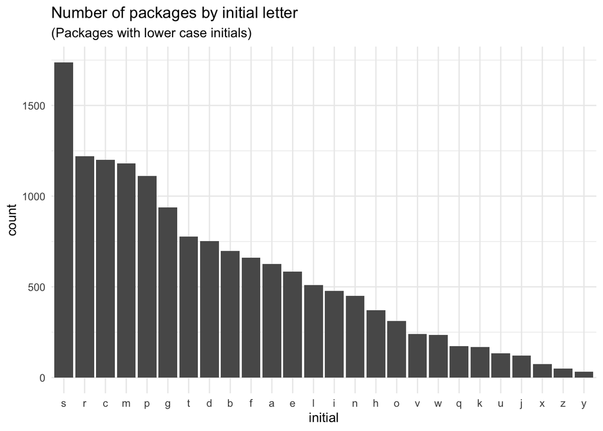

```r
# your code
filtered_package = tibble(package= dat$package[str_detect(dat$package, "^[a-z]")])
initial_package = mutate(filtered_package, initial = substring(package, 1, 1))
sorted_data = initial_package |>
  group_by(initial) |>
  count(initial)

ggplot(data = sorted_data, aes(x = reorder(initial, desc(n)), y = n)) +
  geom_bar(stat='identity') +
  labs(title = "Number of packages by initial letter",
       subtitle = "(Packages with lower case initials)",
       x = "initial",
       y = "count") +
  theme_minimal()
```

## 6.2 Upper case initials

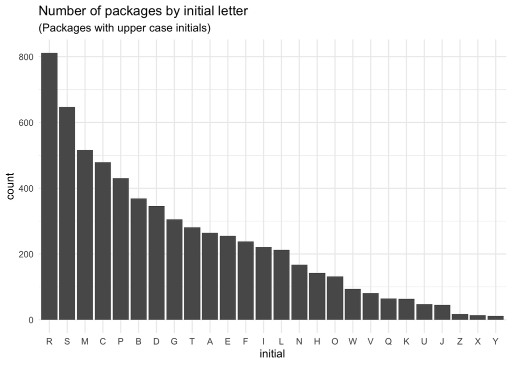

```r
# your code
filtered_package = tibble(package= dat$package[str_detect(dat$package, "^[A-Z]")])
initial_package = mutate(filtered_package, initial = substring(package, 1, 1))
sorted_data = initial_package |>
  group_by(initial) |>
  count(initial)

ggplot(data = sorted_data, aes(x = reorder(initial, desc(n)), y = n)) +
  geom_bar(stat='identity') +
  labs(title = "Number of packages by initial letter",
       subtitle = "(Packages with upper case initials)",
       x = "initial",
       y = "count") +
  theme_minimal()
```

## 6.3 Upper & Lower case initials

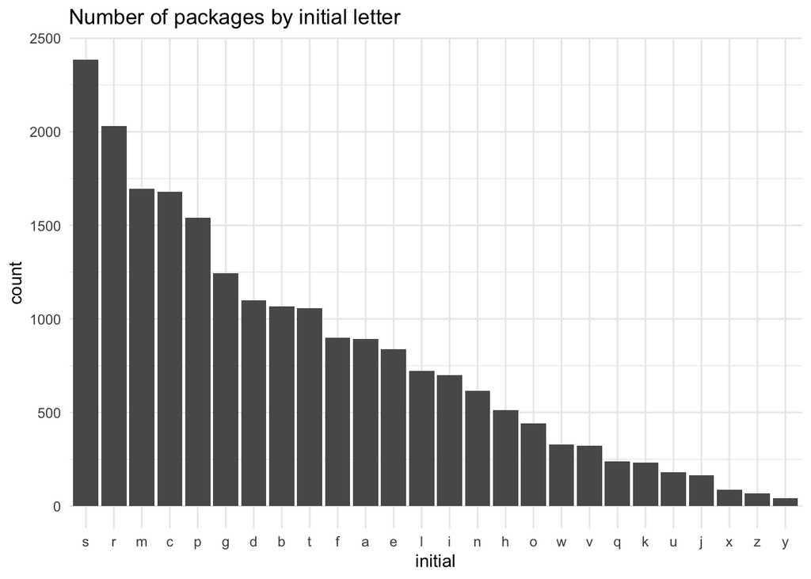

```r
# your code
filtered_package = tibble(package= dat$package[str_detect(dat$package, "^[a-zA-Z]")])
initial_package = mutate(filtered_package, initial = substring(package, 1, 1))
sorted_data = initial_package |>
  group_by(lower = tolower(initial)) |>
  count(lower)

ggplot(data = sorted_data, aes(x = reorder(lower, desc(n)), y = n)) +
  geom_bar(stat='identity') +
  labs(title = "Number of packages by initial letter",
       x = "initial",
       y = "count") +
  theme_minimal()
```